# Python tutorial

(It is inspired by [this tutorial](https://github.com/kuleshov/cs228-material/blob/master/tutorials/python/cs228-python-tutorial.ipynb) and [this tutorial](https://github.com/oseledets/nla2016/blob/master/lectures/Python_Intro.ipynb))

## Basics of Python

### Some facts and references

- Python developing was started in the late 1980s by [Guido van Rossum](https://gvanrossum.github.io/), who worked at CWI institute, Amsterdam. Now he works at Dropbox.

[figure not shown]

- The author called the language in honor of popular British comedy show "Monty Pythons Flying Circus"

[figure not shown]

- Dynamic type system (PHP, Ruby, Javascript, Erlang, etc) vs. static type system (C/C++, Pascal, Java, etc)
- Support multiple programming paradigms
  - object-oriented
  - imperative
  - functional programming
  - procedural
- Python usage in industry and academia:
  - Dropbox was written in Python
  - Google: YouTube, YouTube API and others were written in Python
  - Facebook
  - SciPy stack replaces proprietary tools for scientific computing (MATLAB, Mathemathica)
  - scikit-learn is a popular library for machine learning
  - Web-development
  - Pandas is a popular tool for data processing

#### References

- The Hitchhiker’s Guide to Python: http://docs.python-guide.org/en/latest/
- Hard way is easier: http://learnpythonthehardway.org
- Python crash course from Google: https://developers.google.com/edu/python/
- Official tutorial: https://docs.python.org/2/tutorial/
- Python Tutor - code visualization (developed by MIT): http://pythontutor.com/
- If you feel lost: https://www.codecademy.com/en/tracks/python
- Related course in HSE here

#### Advanced references

- Al Sweigart, "Automate the Boring Stuff with Python", https://automatetheboringstuff.com
- Mark Lutz, "Python Pocket Reference" (250 pages)
- Mark Lutz, "Learning Python" (1600 pages!)

#### The Zen of Python, by Tim Peters

```python
import this
```

```
The Zen of Python, by Tim Peters

Beautiful is better than ugly.
Explicit is better than implicit.
Simple is better than complex.
Complex is better than complicated.
Flat is better than nested.
Sparse is better than dense.
Readability counts.
Special cases aren't special enough to break the rules.
Although practicality beats purity.
Errors should never pass silently.
Unless explicitly silenced.
In the face of ambiguity, refuse the temptation to guess.
There should be one-- and preferably only one --obvious way to do it.
Although that way may not be obvious at first unless you're Dutch.
Now is better than never.
Although never is often better than *right* now.
If the implementation is hard to explain, it's a bad idea.
If the implementation is easy to explain, it may be a good idea.
Namespaces are one honking great idea -- let's do more of those!
```

#### How to write code

- First of all your code has to be readable!
  - Other people can easily understand what your code means and what operations it performs
  - Variable, function and class names have to be meaningful
  - Style of your code has to be consistent: formatting, spaces, etc
- Style giudes:
  - [PEP8](http://legacy.python.org/dev/peps/pep-0008/) (PEP = Python Enhancement Proposal)
  - [Google Python style guide](https://google.github.io/styleguide/pyguide.html)
  - write idiomatic code http://python.net/~goodger/projects/pycon/2007/idiomatic/handout.html

#### Python installation

- In this course we will use [Python 3.6 from Anaconda distribution](https://www.anaconda.com/download/)
- Install it if you didn't do it earlier

#### Python 2 vs. Python 3

Check your Python version:

```
python --version
```

This course uses Python 3

Main changes in Python 3

- Key word `print` becomes function
- `xrange()` is replaced by `range()`
- Integer division
- Some methods return iterators, not lists
- Support Unicode

### Data types

- Number
- String
- Booleans

#### Numbers

- Float
- Complex

```python
import math

a = 12
b = 3
print(a + b)
print(a - b)
print(a * b)
print(b**a)
print(b / a)
print(b // a)
print(a % 5)
print(math.sqrt(12))
```

```
15
9
36
531441
0.25
0
2
3.4641016151377544
```

```python
a = 1 + 1j
b = 2 + 2j
print(a + b)
print(abs(a))
print(a * b)
print(a - b)
print(b**a)
```

```
(3+3j)
1.4142135623730951
4j
(-1-1j)
(-0.3244472096893367+1.2481068139109326j)
```

- No unary operaors ++ and --

```python
a += b
print(a, b)
a-= b
print(a, b)
a *= b
print(a, b)
a /= b
print(a)
```

```
(3+3j) (2+2j)
(1+1j) (2+2j)
4j (2+2j)
(1+1j)
```

```python
import numpy as np

x = np.pi / 2
print(np.sin(x))
print(np.exp(x))
print(np.cos(x))
print(np.tan(x))
print(np.sqrt(x))
```

```
1.0
4.810477380965351
6.123233995736766e-17
1.633123935319537e+16
1.2533141373155001
```

#### String

- Immutable type
- Sequence of symbols
- Indexing and slicing

```python
mystring = "Moscow State University"
print(mystring)
print(mystring[0])
print(mystring[4:])
print(mystring[:5])
print(mystring[2:10])
print(mystring[2:10:2])
```

```
Moscow State University
M
ow State University
Mosco
scow Sta
so t
```

```python
print(mystring)
print(mystring[-1])
print(mystring[-5:])
print(mystring[:-2])
print(mystring[-10:-4])
print(mystring[-10:-4:2])
print(mystring[::-1])
mystring[0] = "K" # Since strings are immutable
```

```
Moscow State University
y
rsity
Moscow State Universi
Univer
Uie
ytisrevinU etatS wocsoM
```

```
---------------------------------------------------------------------------
TypeError                                 Traceback (most recent call last)
<ipython-input-8-6d8c380d8c09> in <module>()
      6 print(mystring[-10:-4:2])
      7 print(mystring[::-1])
----> 8 mystring[0] = "K"

TypeError: 'str' object does not support item assignment
```

- Formatting output

```python
sent = "The most famous university in Russia is {}".format(mystring)
print(sent)
sent = "The most famous university in {} is {}".format("Russia", mystring)
print(sent)
sent = "The most famous university in {1} is {0}".format("Russia", mystring)
print(sent)
```

```
The most famous university in Russia is Moscow State University
The most famous university in Russia is Moscow State University
The most famous university in Moscow State University is Russia
```

```python
print("The number pi is {1:.10f} and the number e is {0:.25f}".format(math.e, math.pi))
print("The number e is {:.5f}".format(math.e))
```

```
The number pi is 3.1415926536 and the number e is 2.7182818284590450907955983
The number e is 2.71828
```

- String methods always return new string, no inplace operations

```python
mystring = "moscow is a capital of russia   "
print(mystring)
print(mystring.capitalize())
print(mystring.upper())
print("Moscow".lower())
print(mystring.strip())
print(mystring.replace("o", "cas"))
print(len(mystring))
print(len(mystring.strip()))
```

```
moscow is a capital of russia
Moscow is a capital of russia
MOSCOW IS A CAPITAL OF RUSSIA
moscow
moscow is a capital of russia
mcassccasw is a capital casf russia
32
29
```

- Concatenation - always save result in a new string

```python
w1 = "MSU"
w2 = "CMC"
w3 = w1 + " " + w2
print(w3)
```

```
MSU CMC
```

#### Booleans

- True
- False

```python
t = True
f = False
print(t and f)
print(not t)
print(t or f)
print(t != f)  # XOR
```

```
False
False
True
True
```

```python
a, b = 10, 5
print(a, b)
a, b = b, a   # Fast swap
print(a, b)
print(a == b)
print(a > b)
print(a < b)
print(a >= b)
```

```
10 5
5 10
False
False
True
False
```

### Conditions and loops

- if-elif-else
- for-loop
- while-loop

#### if-elif-else

```
if condition1:
    pass
elif condition2:
    pass
else:
    pass
```

- Execute body of block that is first true

```python
# Try different x
x = 40
if x > 50:
    x /= 2
elif x > 70:
    x += 10
else:
    x = 0
print(x)
```

```
0
```

#### for-loop

```
for a in sequence:
    pass
else:
    pass
```

- Iterations over sequential data
- May have `else` statement in the end to check success iterations over all elements of `sequence` without breaks or exceptions

```python
# mystring = "Moscow"
mystring = "MSU CMC"
for letter in mystring:
    if letter != " ":
        print(letter)
    else:
        break
else:
    print("Check all letters!")
```

```
M
S
U
```

```python
# Iteration over  numbers
n = 10
for i in range(n):
    if i % 2 == 0:
        print(i)
```

```
0
2
4
6
8
```

#### while-loop

```
while condition:
    pass
else:
    pass
```

- The same as for-loop but we do not know when this loop will be finished
- The same for `else` statement

```python
n = 10
while n > 0:
    n -= 1
    print(n)
else:
    print("OK!")
```

```
9
8
7
6
5
4
3
2
1
0
OK!
```

```python
m = 8
while True:
    if m % 2 == 0:
        m /= 2
    else:
        break
    print(m)
else:
    print("OK!")
```

```
4.0
2.0
1.0
```

### Built-in containers

| C++ | Python |
| --- | --- |
| `std::vector` | list |
| `std::map` | dict |
| `std::set` | set |
| `std::tuple` | tuple |

#### List

- Mutable type
- Store elements of different types
- Resizeable
- Indexing and slicing are similar to string
- Complete docs [here](https://docs.python.org/3/tutorial/datastructures.html)

```python
l1 = [1, 20, 30, -3]
print(l1)
l2 = [10, "Russia", True]
print(l2)
print(l1[0])
l1[0] = 1000
print(l1)
l1.insert(10, "insert")
print(l1)
l1[11] = "test"   # This won't work
l1.append('testik')
l1
```

```
[1, 20, 30, -3]
[10, 'Russia', True]
1
[1000, 20, 30, -3]
[1000, 20, 30, -3, 'insert']
```

```
---------------------------------------------------------------------------
IndexError                                Traceback (most recent call last)
<ipython-input-25-cd7975110ee2> in <module>()
      8 l1.insert(10, "insert")
      9 print(l1)
---> 10 l1[11] = "test"   # This won't work
     11 l1.append('testik')
     12 l1

IndexError: list assignment index out of range
```

```python
for element in l1:
    print(element)
```

```
1000
20
30
-3
insert
```

```python
l1.append("False")
print(l1)
final_value = l1.pop()
print(final_value, l1)
l1.reverse()
print(l1)
```

```
[1000, 20, 30, -3, 'insert', 'False']
False [1000, 20, 30, -3, 'insert']
['insert', -3, 30, 20, 1000]
```

```python
print(l1 + l2)
print(2 * l1)
print(2 * [l1])
l1 += l2
print(l1)
# print(l1 - l2)
```

```
['insert', -3, 30, 20, 1000, 10, 'Russia', True, 10, 'Russia', True]
['insert', -3, 30, 20, 1000, 10, 'Russia', True, 'insert', -3, 30, 20, 1000, 10, 'Russia', True]
[['insert', -3, 30, 20, 1000, 10, 'Russia', True], ['insert', -3, 30, 20, 1000, 10, 'Russia', True]]
['insert', -3, 30, 20, 1000, 10, 'Russia', True, 10, 'Russia', True]
```

- List comprehension

```python
nums = [0, 1, 2, 3, 4]
squares = []
for x in nums:
    squares.append(x ** 2)
print(squares)
# Or
squares = [x ** 2 for x in nums]
print(squares)
# And with if
even_squares = [x ** 2 for x in nums if x % 2 == 0]
print(even_squares)
```

```
[0, 1, 4, 9, 16]
[0, 1, 4, 9, 16]
[0, 4, 16]
```

```python
l1= [1,2,3]
l2 = [10, 20, 30]
l = [l1, l2]
print(l)
l1[0] = 123
print(l)
l[1][2] = "test"
print(l2)
```

```
[[1, 2, 3], [10, 20, 30]]
[[123, 2, 3], [10, 20, 30]]
[10, 20, 'test']
```

#### Tuple

- Immutable type as a string
- Indexing and slicing work again
- Packing and unpacking variables

```python
t1 = (1, 2)
l1 = [1, 2]
print(t1, "Required {} bytes".format(t1.__sizeof__()))
print(l1, "Required {} bytes".format(l1.__sizeof__()))
```

```
(1, 2) Required 40 bytes
[1, 2] Required 56 bytes
```

```python
print(t1[0], t1[1])
# print(t1[3])
```

```
1 2
```

```python
t3 = t1 + (4, 5)
print(t3)
print(t3[1:3])
print(t3[::-1])
# t3[3] = 4
```

```
(1, 2, 4, 5)
(2, 4)
(5, 4, 2, 1)
```

```python
t4 = ([1,2], [10, 20])
print(t4)
t4[0][0] = 10
print(t4)
# t4[0] = 5
```

```
([1, 2], [10, 20])
([10, 2], [10, 20])
```

```python
t5 = ()
print(len(t5))
t5 = 1,
print(len(t5))
```

```
0
1
```

```python
t6 = ("apple", "blueberry", "orange")
apple, bb, orange = t6
print(apple, bb, orange)
```

```
apple blueberry orange
```

```python
l1 = [(i, i**2) for i in range(10)]
print(l1)
```

```
[(0, 0), (1, 1), (2, 4), (3, 9), (4, 16), (5, 25), (6, 36), (7, 49), (8, 64), (9, 81)]
```

#### Dict

- Store (key, value) pairs
- Key has to be immutable type
- Values for keys can be changed
- Add new pairs

```python
d = {"cat": 12, "dog": 40}
print(d)
print(d["cat"])
print("cat" in d)
```

```
{'cat': 12, 'dog': 40}
12
True
```

```python
d["fox"] = 34
print(d)
d[(1,2,3)] = "tuple"
d[[1, 2, 3]] = "list"
```

```
{'cat': 12, 'dog': 40, 'fox': 34}
```

```
---------------------------------------------------------------------------
TypeError                                 Traceback (most recent call last)
<ipython-input-44-0c27e8dc2b88> in <module>()
      2 print(d)
      3 d[(1,2,3)] = "tuple"
----> 4 d[[1, 2, 3]] = "list"

TypeError: unhashable type: 'list'
```

```python
for key in d:
    print(key, d[key])
```

```
cat 12
dog 40
fox 34
(1, 2, 3) tuple
```

```python
for key in d:
    print(key)
```

```
cat
dog
fox
(1, 2, 3)
```

```python
for val in d.values():
    print(val)
```

```
12
40
34
tuple
```

```python
for k, v in d.items():
    print(k, v)
```

```
cat 12
dog 40
fox 34
(1, 2, 3) tuple
```

- Dict comprehensions

```python
d2 = {key: 2*key for key in [1,2,3]}
print(d2)
```

```
{1: 2, 2: 4, 3: 6}
```

#### Set

- Unordered collection with no duplicate elements
- Support mathematical operations like union, intersection, difference, and symmetric difference
- Complete docs [here](https://docs.python.org/3/tutorial/datastructures.html#sets)

```python
s = set()
print(s)
string = "abracadabra"
s = set(string)
print(s, len(s))
s.add("y")
print(s, len(s))
s.remove("a")
print(s, len(s))
```

```
set()
{'r', 'd', 'b', 'a', 'c'} 5
{'y', 'r', 'd', 'b', 'a', 'c'} 6
{'y', 'r', 'd', 'b', 'c'} 5
```

```python
s1 = set([1,2,3,2,56])
s2 = set([2,45,10])
print(s1 - s2)
print(s1 & s2)
print(s1 ^ s2)
print(s1 | s2)
```

```
{56, 1, 3}
{2}
{1, 3, 10, 45, 56}
{1, 2, 3, 56, 10, 45}
```

### Other containers

- You can use other containers, which are available in module [collections](https://docs.python.org/3/library/collections.html)
- Just import it

  ```
  import collections
  ```

  and you have other containers
  - Deque
  - OrderedDict
  - ...

### Functions

```
def function_name(arguments):
#     make something
    return something
```

```python
def sign(x):
    if x > 0:
        return 'positive'
    elif x < 0:
        return 'negative'
    else:
        return 'zero'

for x in [-1, 0, 2]:
    print(sign(x))
```

```
negative
zero
positive
```

```python
def say_hello(name, loud=False):
    if loud:
        print('HELLO, {}'.format(name.upper()))
    else:
        print('Hello, {}!'.format(name))

say_hello('Ivan')
say_hello('George', loud=True)
```

```
Hello, Ivan!
HELLO, GEORGE
```

```python
def test_func(x, *args, **kwargs):
    print(x)
    print("args elements")
    for l in args:
        print(l)
    print("kwargs elements")
    for key in kwargs:
        print(key, kwargs[key])

test_func(10, 100, "string", s1=10, r2=(1,67))
```

```
10
args elements
100
string
kwargs elements
s1 10
r2 (1, 67)
```

### Classes

- Syntax of class defining is straightforward
- No destructors, because of garbage collector works
- All methods are virtual and all members are public
- But you can make memebers private with special approaches
- Complete doc is [here](https://docs.python.org/3/tutorial/classes.html)

```python
class Greeter:

    # Constructor
    def __init__(self, name):
        self.name = name  # Create an instance variable

    # Instance method
    def greet(self, loud=False):
        if loud:
            print('HELLO, {}!'.format(self.name.upper()))
        else:
            print('Hello, {}'.format(self.name))

g = Greeter('John')  # Construct an instance of the Greeter class
g.greet()            # Call an instance method; prints "Hello, Fred"
g.greet(loud=True)   # Call an instance method; prints "HELLO, FRED!"
```

```
Hello, John
HELLO, JOHN!
```

### Modules

- You can import modules with command

  ```
  import module_name
  ```

  and use functions from this module as

  ```
  module_name.func()
  ```

- Other way is to use aliases

  ```
  import module_name as mn
  ```

  and use functions from this module as

  ```
  mn.func()
  ```

- Other ways of importing are not appropriate

### Exerсises

1. Implement bubble-sort, merge-sort and quick-sort algorithms as three functions with input argument — array and output is sorted array. Compare its running time depending on the size of array and also compare running time your functions with built-in method `sort`. Plot lines time vs. array size for every sorting algorithm. Time has to be computed with [%timeit magic](http://ipython.readthedocs.io/en/stable/interactive/magics.html). How plot lines see further in this notebook.
2. Show convergence of Taylor expansion for functions $\sin(x)$, $e^x$ and $\frac{1}{1 - x}$. Plot approximation error vs. number of items in sum. Compare different strategies of ordering items in sum. To compute required functions use `numpy` library
3. Implement function that tests if given number is prime or not. Input is positive integer, output is `True` or `False`.

```python
# Your code is here
```

## NumPy, SciPy & Matplotlib

- Numpy is the core library for scientific computing in Python
- It provides a high-performance multidimensional array object, and tools for working with these arrays
- For Matlab users [here](http://scipy.github.io/old-wiki/pages/NumPy_for_Matlab_Users) is great tutorial
- SciPy provides tools for working with sparse matrices
- Matplotlib is a library to plot your data

### NumPy

```python
import numpy as np

n = 5
print(np.zeros(n))
print(np.ones(n))
print(np.random.rand(n))
print(np.random.randn(n))
print(np.random.randint(n, size=n))
print(np.eye(n))
```

```
[0. 0. 0. 0. 0.]
[1. 1. 1. 1. 1.]
[0.73656041 0.93382644 0.43383646 0.42223709 0.06284563]
[ 0.36866016  1.33655503  0.25258837 -0.06901819  1.72913837]
[0 1 3 4 4]
[[1. 0. 0. 0. 0.]
 [0. 1. 0. 0. 0.]
 [0. 0. 1. 0. 0.]
 [0. 0. 0. 1. 0.]
 [0. 0. 0. 0. 1.]]
```

```python
x = np.array([i for i in range(n)])
print(x, x.shape)
y = np.random.rand(n)
print(y)
print(x + y)
print(x - y)
print(2 * x)
print(x / y)
print(np.power(x, 2))
print(np.sqrt(x))
print(x.dot(y))
print(np.linalg.norm(x)**2, x.dot(x))
```

```
[0 1 2 3 4] (5,)
[0.09342036 0.92236004 0.6822449  0.7139277  0.31775153]
[0.09342036 1.92236004 2.6822449  3.7139277  4.31775153]
[-0.09342036  0.07763996  1.3177551   2.2860723   3.68224847]
[0 2 4 6 8]
[ 0.          1.08417533  2.93149867  4.20210619 12.58845221]
[ 0  1  4  9 16]
[0.         1.         1.41421356 1.73205081 2.        ]
5.699639058366479
30.0 30
```

- Slicing is the same as for lists but slicing for numpy array returns **view** not a copy!

```python
x_slice = x[:3]
print(x_slice)
x_slice[0] = 1000
print(x, x_slice)
x_copy = x[:3].copy()
x_copy[0] = -1000
print(x, x_copy)
```

```
[0 1 2]
[1000    1    2    3    4] [1000    1    2]
[1000    1    2    3    4] [-1000     1     2]
```

```python
m, n = 3, n
X = np.random.rand(m, n)
print(X, x)
print(X.dot(x))
print(X + x)
print(X * x)
print(X - x)
print(X / x)
```

```
[[0.67386614 0.87788974 0.55034435 0.56525508 0.98623144]
 [0.97144278 0.44477014 0.27003625 0.35828551 0.61902225]
 [0.83812451 0.90143581 0.53184855 0.33523693 0.88813952]] [1000    1    2    3    4]
[681.48540469 975.97856595 844.64790682]
[[1000.67386614    1.87788974    2.55034435    3.56525508    4.98623144]
 [1000.97144278    1.44477014    2.27003625    3.35828551    4.61902225]
 [1000.83812451    1.90143581    2.53184855    3.33523693    4.88813952]]
[[6.73866135e+02 8.77889740e-01 1.10068869e+00 1.69576523e+00
  3.94492574e+00]
 [9.71442778e+02 4.44770135e-01 5.40072497e-01 1.07485653e+00
  2.47608899e+00]
 [8.38124505e+02 9.01435807e-01 1.06369711e+00 1.00571078e+00
  3.55255807e+00]]
[[-9.99326134e+02 -1.22110260e-01 -1.44965565e+00 -2.43474492e+00
  -3.01376856e+00]
 [-9.99028557e+02 -5.55229865e-01 -1.72996375e+00 -2.64171449e+00
  -3.38097775e+00]
 [-9.99161875e+02 -9.85641933e-02 -1.46815145e+00 -2.66476307e+00
  -3.11186048e+00]]
[[6.73866135e-04 8.77889740e-01 2.75172173e-01 1.88418358e-01
  2.46557859e-01]
 [9.71442778e-04 4.44770135e-01 1.35018124e-01 1.19428504e-01
  1.54755562e-01]
 [8.38124505e-04 9.01435807e-01 2.65924277e-01 1.11745642e-01
  2.22034880e-01]]
```

```python
print(np.random.rand(3, 4).dot(x))
```

```
---------------------------------------------------------------------------
ValueError                                Traceback (most recent call last)
<ipython-input-61-9dfccd37c7aa> in <module>()
----> 1 print(np.random.rand(3, 4).dot(x))

ValueError: shapes (3,4) and (5,) not aligned: 4 (dim 1) != 5 (dim 0)
```

```python
X = np.random.rand(n, n)
Y = np.random.rand(n, m)
print(X.dot(Y))
print(X + Y)
```

```
[[1.16839889 2.08712882 2.10651934]
 [0.96148482 2.1657093  2.10516476]
 [0.71909222 1.56909785 1.4395249 ]
 [1.33096475 1.81743333 2.45744438]
 [1.28262143 2.71700362 2.54741346]]
```

```
---------------------------------------------------------------------------
ValueError                                Traceback (most recent call last)
<ipython-input-62-6fcc4258d71e> in <module>()
      2 Y = np.random.rand(n, m)
      3 print(X.dot(Y))
----> 4 print(X + Y)

ValueError: operands could not be broadcast together with shapes (5,5) (5,3)
```

```python
X = np.random.rand(m, n)
print(X)
print(X[:, 0])
print(X[-1, :])
print(X[::2, :])
print(X[:3, :-1])
print(X[1:, 1])
```

```
[[0.73611375 0.17769019 0.46688393 0.83210923 0.80990758]
 [0.89984313 0.92056154 0.7390683  0.40031946 0.94040725]
 [0.30320763 0.66888045 0.98457455 0.20539282 0.83519665]]
[0.73611375 0.89984313 0.30320763]
[0.30320763 0.66888045 0.98457455 0.20539282 0.83519665]
[[0.73611375 0.17769019 0.46688393 0.83210923 0.80990758]
 [0.30320763 0.66888045 0.98457455 0.20539282 0.83519665]]
[[0.73611375 0.17769019 0.46688393 0.83210923]
 [0.89984313 0.92056154 0.7390683  0.40031946]
 [0.30320763 0.66888045 0.98457455 0.20539282]]
[0.92056154 0.66888045]
```

```python
print(X)
print(np.linalg.norm(X))
print(np.trace(X))
print(np.diag(X))
print(X[X > 0.1])
print(X.reshape(1, 15))
```

```
[[0.73611375 0.17769019 0.46688393 0.83210923 0.80990758]
 [0.89984313 0.92056154 0.7390683  0.40031946 0.94040725]
 [0.30320763 0.66888045 0.98457455 0.20539282 0.83519665]]
2.763373147327656
2.641249833535194
[0.73611375 0.92056154 0.98457455]
[0.73611375 0.17769019 0.46688393 0.83210923 0.80990758 0.89984313
 0.92056154 0.7390683  0.40031946 0.94040725 0.30320763 0.66888045
 0.98457455 0.20539282 0.83519665]
[[0.73611375 0.17769019 0.46688393 0.83210923 0.80990758 0.89984313
  0.92056154 0.7390683  0.40031946 0.94040725 0.30320763 0.66888045
  0.98457455 0.20539282 0.83519665]]
```

```python
print(X.min())
print(X.sum())
print(X.sum(axis=0))
print(X.max())
print(X.mean())
```

```
0.17769018970386996
9.920156449351238
[1.93916452 1.76713218 2.19052677 1.4378215  2.58551148]
0.9845745494200443
0.6613437632900825
```

- NumPy includes implementations of almost any mathematical function and applies it element-wise to array
- Complete doc is [here](https://docs.scipy.org/doc/numpy-1.13.0/reference/)

```python
args = np.arange(0, 2.5*np.pi, 0.5*np.pi)
print(np.sin(args))
print(np.cos(args))
```

```
[ 0.0000000e+00  1.0000000e+00  1.2246468e-16 -1.0000000e+00
 -2.4492936e-16]
[ 1.0000000e+00  6.1232340e-17 -1.0000000e+00 -1.8369702e-16
  1.0000000e+00]
```

```python
n = 100
A = np.random.rand(n, n)
x_true = np.random.randn(n)
b = A.dot(x_true)
x = np.linalg.solve(A, b)
print(np.linalg.norm(x - x_true))
```

```
2.820412884586997e-13
```

```python
# Try test numpy functions for your own research routines (optional)
```

### SciPy

```python
import scipy.sparse as spsp

main_diagonal = -2 * np.ones(n, )
suddiag_values = np.ones(n - 1,)
diagonals = [main_diagonal, suddiag_values, suddiag_values]
offsets = [0, 1, -1]
A = spsp.diags(diagonals, offsets, shape=(n, n), format='csr')
```

- A lot of stuff for sparse matrices in different formats
- Various functions about optimization, approximation, FFT, statistics, special functions and others
- Complete doc is [here](https://docs.scipy.org/doc/scipy/reference/)

### Matplotlib

- Library to plot different linea nd figures in 2D and 3D
- Tutorial for beginners is [here](https://matplotlib.org/users/pyplot_tutorial.html) and more complete one is [here](https://matplotlib.org/users/beginner.html)
- You can tune all parameters of plot: labels, legends, fontsize, colours, ticks, markers, linewidth and many, many others
- Label strings support $\TeX$ notation

```python
%matplotlib inline
import matplotlib.pyplot as plt
from mpl_toolkits.mplot3d import Axes3D
```

```
Text(0.5,1,'Parabola $y = x^2$')
```

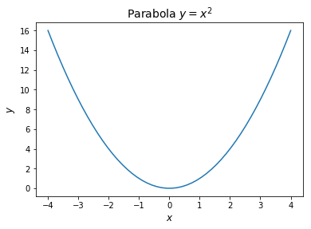

```python
x = np.linspace(-4, 4)
y = np.power(x, 2)
plt.plot(x, y)
plt.xlabel("$x$", fontsize=12)
plt.ylabel("$y$", fontsize=12)
plt.title("Parabola $y = x^2$", fontsize=14)
```

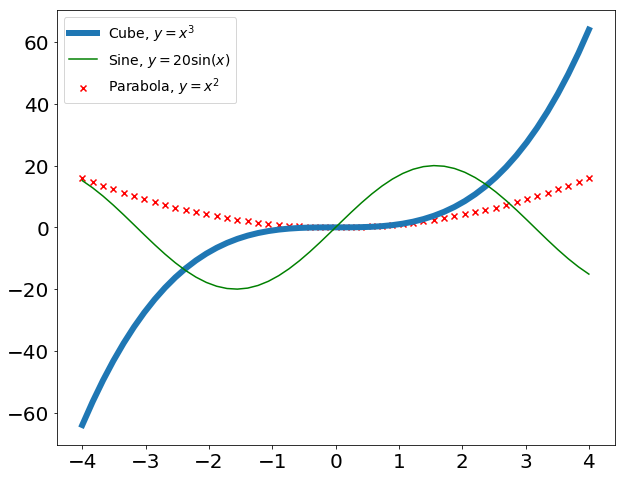

```python
plt.figure(figsize=(10, 8))
plt.scatter(x, y, marker="x", label="Parabola, $y = x^2$", color="red")
plt.plot(x, x**3, label="Cube, $y = x^3$", linewidth=6)
plt.plot(x, 20 * np.sin(x), color="green", label="Sine, $y = 20\sin(x)$")
plt.legend(loc="best", fontsize=14)
plt.xticks(fontsize=20)
_ = plt.yticks(fontsize=20)
```

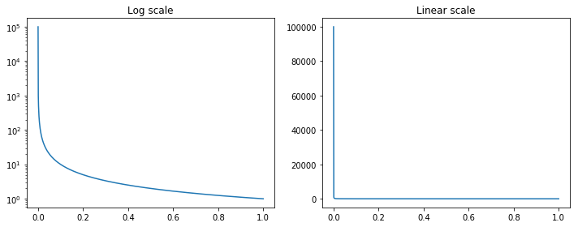

```python
x = np.linspace(1e-5, 1, 1000)
y = 1. / x
plt.figure(figsize=(10,4))
plt.subplot(1,2,1)
plt.plot(x, y)
plt.yscale("log")
plt.title("Log scale")

plt.subplot(1,2,2)
plt.plot(x, y)
plt.title("Linear scale")
plt.tight_layout()
```

```
Text(0.5,0.92,'The plot of $f(x, y) = \\sin(x+y)$')
```

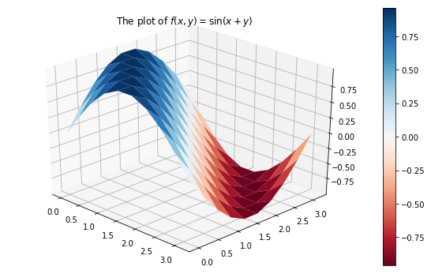

```python
linear_index = np.linspace(0, np.pi, 10, endpoint=True)
mesh_x, mesh_y = np.meshgrid(linear_index, linear_index)
values_3D = np.sin(mesh_x + mesh_y)

fig = plt.figure(figsize=(10,6))
ax = fig.gca(projection="3d")

surf = ax.plot_surface(mesh_x, mesh_y, values_3D, cmap="RdBu")
ax.view_init(azim=-45, elev=30)
fig.colorbar(surf)
plt.title('The plot of $f(x, y) = \sin(x+y)$')
```

### General rules about plots

- Legends, labels, titles, ticks must be readable!
- If most part of line is near 0, use log-scale for y-axis. The same is true for x-axis if necessary
- Plot lines about the same issue in one plot

### Exercises

1. Generate random low-rank matrix $500 \times 500$ with rank $r = 10$, perform its SVD and plot how decreases singular values
2. Compare running time of square lowrank matrix by vector multiplication in two cases:
   - Matrix is given in lowrank format, i.e. product of 2 lowrank matrices
   - Matrix is given as it is  
     Plot graphs time vs. dimension of the matrix for these two cases. Add legend and axis labels.
3. Plot density function of normal distribution in 1D and 2D cases for the following parameters:
   - $\mu = 0, \sigma = 1$
   - $\mu = 1.5, \sigma = 0.1$
   - $\mu = -0.5, \sigma = 3$
   - $\mu = (1, 1), \Sigma = \begin{bmatrix} 2 & 0\\ 0 & 1 \end{bmatrix}$
   - $\mu = (-1, 1), \Sigma = \begin{bmatrix} 2 & 0.1\\ 1 & 1 \end{bmatrix}$

For 1D case you can plot all lines in the single plot with legend. For 2D case use separate plots, add titles with corresponding parameters and colorbars.

```python
# Your code is here
```